# End of Class Plotting Assignment

Gian Wegmueller

09 Februar, 2025

# Dependencies

```r
library(readr)
library(dplyr)
library(tidyr)
library(janitor)
library(stringr)
library(trackeR)
library(leaflet)
library(ggplot2)
library(ggtext)
library(hrbrthemes)
library(knitr)
```

# Data Wrangling

## Data Preparation Drug Use - Bad Plot

The data for the bad plot stem from [FiveThirtyEight’s](https://github.com/fivethirtyeight/data/tree/master/drug-use-by-age) GitHub repository and are open access. There’s also an article from 2015 titled [“How Baby Boomers Get High”](https://fivethirtyeight.com/features/how-baby-boomers-get-high/) on their website.

```r
## read drug use data
drugs_raw <- read_csv("../data/drug_use_by_age.csv")

drugs_comparison <- drugs_raw %>%
  select(age, n,
         starts_with(c("alcohol", "marijuana", "cocaine", "meth"))) %>% # select variables of interest
  filter(age %in% c("21", "22-23", "24-25", "26-29", "50-64")) %>% #choosing only legal drinking-age Millennials for comparison here
  mutate(cocaine_frequency = as.numeric(cocaine_frequency), # transform non-numeric variables to numeric
         meth_frequency = as.numeric(meth_frequency),
         generation = if_else(age == "50-64", "Boomers", "Millennials")) %>% # create new variable 'generation'

  # calculating mean of median values for Millennials, since there are multiple age categories for this generation (Baby Boomers only have 1 value)
  group_by(generation) %>%
  summarize(booze_med_freq = janitor::round_half_up(weighted.mean(alcohol_frequency, n), 1), # round to 1 decimal
            pot_med_freq = janitor::round_half_up(weighted.mean(marijuana_frequency, n), 1),
            coke_med_freq = janitor::round_half_up(weighted.mean(cocaine_frequency, n), 1),
            meth_med_freq = janitor::round_half_up(weighted.mean(meth_frequency, n), 1)) %>%
  pivot_longer(cols = booze_med_freq:meth_med_freq, # transform to long format for easier plotting
               names_to = "drug",
               values_to = "median_freq")
```

## Data Preparation Lucerne Half-Marathon - Good Plot

The good plot visualizes my personal heart rate data from the **Lucerne City Half-Marathon** on October 27, 2024. I tracked the race with a *Garmin Forerunner 255* running watch, which I have been using since July to collect training and overall fitness data. The *Garmin Connect* website allows you to download various types of information from all your activities, including GPS, pace, and heart rate data. According to the Garmin Connect log for the Lucerne Half-Marathon, my heart rate zones at the time of the race were:

- **Zone 1**: 98 - 116 bpm
- **Zone 2**: 117 - 136 bpm
- **Zone 3**: 137 - 155 bpm
- **Zone 4**: 156 - 175 bpm
- **Zone 5**: $\geq$ 176 bpm

```r
# loading the Garmin Connect activity data (requires readTCX-function from package trackeR)
lucerne_half_24 <- readTCX("../data/lucerne_half_2024.tcx")

# creating subset with variables of interest
lucerne_half_24_bpm <- lucerne_half_24 %>%
  select(latitude, longitude, distance, heart_rate) %>% # selecting variables of interest

  mutate(distance_km = distance/1000, # creating distance_km variable by dividing 'distance' by 1000, the latter is specified in metres

         # creating heart_rate_zone variable, zones according to information on Garmin Connect
         heart_rate_zone = as.factor(case_when(heart_rate >= 137 & heart_rate <= 155 ~ "Zone 3",
                                               heart_rate >= 156 & heart_rate <= 175 ~ "Zone 4",
                                               heart_rate >= 176 ~ "Zone 5"))) %>%
  # reorder columns in data frame
  relocate(latitude, longitude, distance_km, distance, heart_rate, heart_rate_zone)


### SLICED DATASET FOR INTERACTIVE MAP ###
# Due to the large number of observations in the complete dataset, the loop for rendering the interactive map takes up a lot of computational resources. Slicing the dataset in half by deleting every second row still retains more than enough data points to create a map without any significant loss of information

lucerne_half_24_sliced <- lucerne_half_24_bpm %>%
  slice(seq(1, n(), 2))
```

# Plots

## Bad Plot - Median Use Frequency

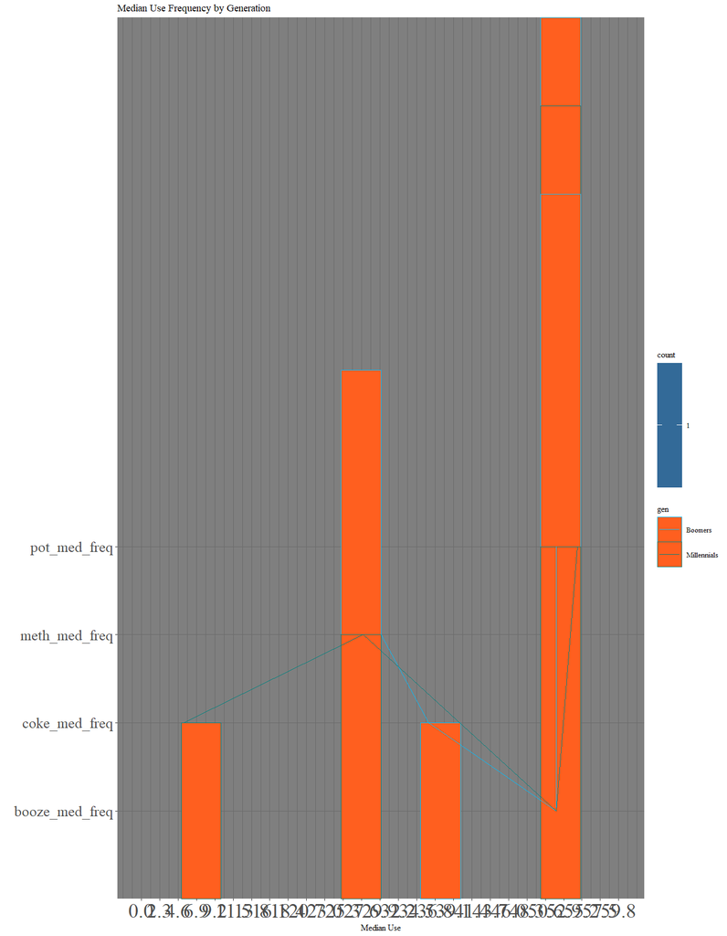

```r
# Bad plot for visualizing median use frequency of 4 different drugs by generation (Boomers & Millennials)
drug_use_plot <- ggplot(data = drugs_comparison, # define data
                 aes(x = median_freq, # median use frequency last 12 months on x-axis
                     y = drug, # type of drug on y-axis
                     colour = generation)) + # colour by generation

  # This geom usually is a useful alternative to geom_point in the presence of overplotting. It divides the plane into rectangles, counts the number of cases in each rectangle, and then maps the number of cases to the rectangle's fill. In this case, it is far from suitable to convey the information...
  geom_bin_2d(position = "stack", # stack bins when equal values
              binwidth = 5,
              fill = "#FF5F1F", # horrible colour to fill bins (too bright)
              show.legend = TRUE) +

  # adding a line to connect the different bins by group, making it appear as if there is some temporal connectivity...
  geom_line(mapping = aes(group = generation),
            linewidth = .2) +

  # setting colour for generations, no contrast and barely visible next to the fill colour
  scale_colour_manual(values = c("#00BFFF", "#00827F")) +

  # specifying x-axis scale
  scale_x_continuous(breaks = seq(0, 60, 2.3), # from 0 to 60 by 2.3, too many breaks, they do not make much sense
                     limits = c(0, 60)) +

  labs(title = "Median Use Frequency by Generation", # ambiguous title
       x = "Median Use", # another vague axis title
       y = "", # no title
       colour = "gen") + # bad title for legend

  theme_dark(base_family = "serif", # base font Times New Roman
             base_size = 6) + # base size way too small
  theme(axis.text.x = element_text(size = 14), # size of x-axis labels
        axis.text.y = element_text(size = 10)) # size of y-axis labels


drug_use_plot
```

### Why is this a bad plot?

The plot obviously has a number of issues:

**1. Colours**

- The fill colour of the bins is too bright and is the same for both generations.
- The frame surrounding the bins is coloured very similarly for both generations, and poses no contrast to the fill colour.
- The background is dark gray, which causes the blue lines to blend right in.
- Colours in general are not colour-blind friendly/accessible.

**2. Axes**

- The x-axis labels are overlapping and completely illegible. Further, they display weird decimal places.
- The y-axis labels are misaligned with the bins, making it impossible to decipher which bin belongs to which drug.
- Further, the y-axis could be mistaken for frequency or count, due to the use of bins.
- Both axes are poorly labelled and scaled

**3. Data Elements**

- Bins are simply the wrong choice for displaying point estimate values
- Bins are stacked, making it impossible to distinguish which bin belongs to which drug
- The line chart implies a temporal trend or change, which is not present at all.
- Line chart is completely unnecessary and confusing

**4. Plot Elements**

- Gridlines make it even more cluttered
- The purpose of the legend “count” is totally unclear in this case
- The “gen” legend is too small and has all the other colour issues as well
- The plot title is also too small and too vague
- And last but not least: the dimensions of the plot are completely off.

## Good Plot - Heart Rate Data from the Lucerne Half-Marathon 2024

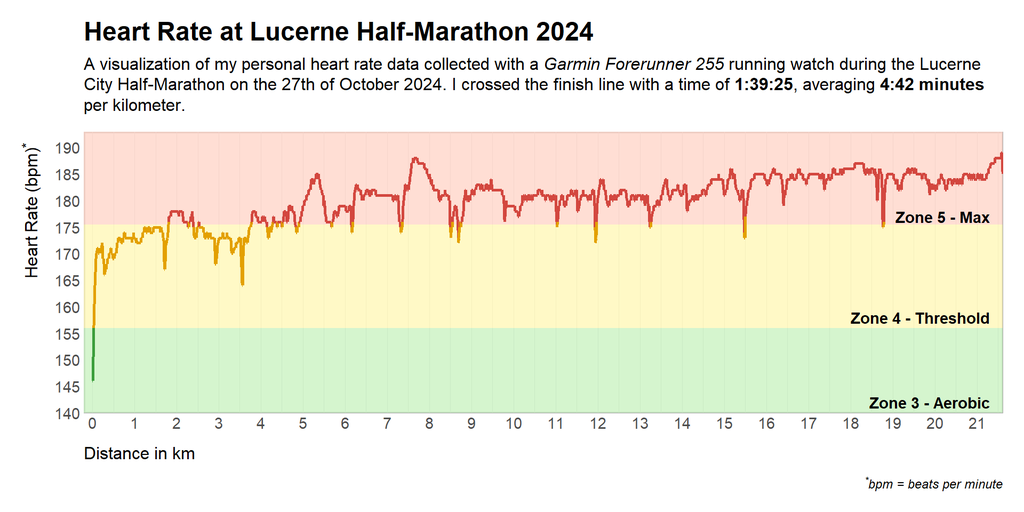

```r
### Defining colour-blind friendly palettes using shades of usual heart rate zone colours.

# palette for colouring background zones in plot
pastel_palette <- c(
  "Zone 3" = "#CAF2C2",
  "Zone 4" = "#FFF8B8",
  "Zone 5" = "#FFD6C9"
)


# line colour palette for contrast
contrast_palette <- c(
  "Zone 3" = "#3B9E3B",
  "Zone 4" = "#E3A000",
  "Zone 5" = "#D3473F"
)

### Plotting

ggplot(data = lucerne_half_24_bpm, # define data
                          aes(x = distance_km, # distance on x-axis
                              y = heart_rate)) + # heart rate on y-axis

  # adding background for Zone 3
  annotate(geom = "rect", xmin = -0.2, xmax = max(lucerne_half_24_bpm$distance_km),
           ymin = 140, ymax = 156, # defining limits on y-axis (156 not 155 as max for neat transition to next zone)
           fill = "#CAF2C2", # Zone 3 colour
           colour = NA, # no frame
           alpha = 0.8) + # setting transparency

  # adding description of Zone 3
  annotate(geom = "text",
           x = 21.3, y = 142, # setting position of text label
           label = "Zone 3 - Aerobic",
           colour = "black",
           fontface = "bold", # format to bold
           hjust = 1) + # right align

  # adding background for Zone 4
    annotate(geom = "rect", xmin = -0.2, xmax = max(lucerne_half_24_bpm$distance_km),
           ymin = 156, ymax = 175.5, # defining limits on y-axis (.5 value for cleaner transition to next zone)
           fill = "#FFF8B8", # Zone 4 colour
           colour = NA, # no frame
           alpha = 0.8) + # setting transparency

  # adding description of Zone 4
    annotate(geom = "text",
             x = 21.3, y = 158,
             label = "Zone 4 - Threshold",
             colour = "black",
             fontface = "bold",
             hjust = 1) +

  # adding background for Zone 5
    annotate(geom = "rect", xmin = -0.2, xmax = max(lucerne_half_24_bpm$distance_km),
           ymin = 175.5, ymax = 193, # defining limits on y-axis
           fill = "#FFD6C9", # Zone 5 colour
           colour = NA, # no frame
           alpha = 0.8) + # setting transparency

  # adding description of Zone 5
    annotate(geom = "text",
             x = 21.3, y = 177,
             label = "Zone 5 - Max",
             colour = "black",
             fontface = "bold",
             hjust = 1) +

  # adding heart rate line to plot
  geom_line(aes(x = distance_km, # setting aesthetics again
                y = heart_rate,
                colour = heart_rate_zone, # colour line according to heart rate zones
                group = 1), # makes sure just one line is added, not three separate lines for each HRZ
            linewidth = 1) + # setting line-thickness

  # defining colours for geom_line
  scale_colour_manual(values = contrast_palette, # using contrast_palette defined above
                      guide = "none") + # no legend

  # formatting x-axis
  scale_x_continuous(breaks = seq(0, max(lucerne_half_24_bpm$distance_km), 1), # adding breaks for every km
                     limits = c(-0.2, max(lucerne_half_24_bpm$distance_km)), # setting limits of scale
                     expand = c(0, 0)) + # get rid of blank space between HRZ and axis

  # formatting y-axis
  scale_y_continuous(breaks = seq(140, 190, 5), # adding breaks from 140 to 190 by steps of 5
                     limits = c(140, 193), # setting limits of scale
                     expand = c(0, 0)) + # get rid of blank space between HRZ and axis

  # adding text and titles
  labs(title = "Heart Rate at Lucerne Half-Marathon 2024",
       subtitle = "A visualization of my personal heart rate data collected with a *Garmin Forerunner 255* running watch during the Lucerne City Half-Marathon on the 27th of October 2024. I crossed the finish line with a time of **1:39:25**, averaging **4:42 minutes** per kilometer.",
       caption = "<sup>*</sup>bpm = beats per minute") +

  xlab("Distance in km") +
  ylab("Heart Rate (bpm)<sup>*</sup>") +

  # setting theme
  theme_ipsum(base_family = "sans", # defining font
              base_size = 11,
              subtitle_size = 12, # setting size for subtitle
              axis_title_size = 12, # setting size for axis titles
              axis_title_just = "lt", # left adjust axis titles
              plot_title_margin = 30, # setting margin for plot title
              subtitle_margin = 30, # setting margin for subtitle
              plot_margin = margin(15,15,15,15)) + # setting margins for plot

  # fine-tuning of theme
  theme(plot.title = element_textbox_simple(margin = margin(b = 15)), # defining margin for title textbox
        plot.subtitle = element_textbox_simple(margin = margin(b = 20)), # defining margin for subtitle textbox, automatic line breaks with element_textbox_simple()
        plot.caption = element_markdown(), # defining caption as markdown element (allows for superscript in text)
        panel.grid.major.y = element_blank(), # getting rid of major...
        panel.grid.minor.y = element_blank(), # ...and minor horizontal gridlines
        panel.background = element_rect(colour = "darkgrey", size = 1), # adding a subtle frame to plot
        axis.title.x = element_text(margin = margin(10,0,0,0)), # setting margin for x-axis title
        axis.title.y = element_markdown(margin = margin(0,10,0,0), # setting margin for y-axis title, and define as markdown to allow for superscript notation
                                        hjust = 0.92)) # moving title on vertical dimension to align better with scale
```

### Why is this a good plot?

**1. Colours:**

- Uses intuitive heart rate zone colours used widely in the endurance sport community.
- Colour shades are colour-blind friendly, making it accessible.
- The lines are coloured in the same way as the heart rate zones, but use darker tones to ensure contrast.

**2. Axes:**

- x-axis is intuitively interpretable, distance increases from left to right.
- y-axis also intuitively interpretable, colouring of heart rate zones aids in interpretation of this axis as well.
- Both axes are clearly titled and labelled, breaks are even and display relevant information.
- Abbreviation “bpm” is explained in caption of plot

**3. Data Elements:**

- Heart rate zones displayed as coloured areas of plot, and clearly labelled with their related endurance information.
- Heart rate displayed as single line, coloured conditionally according to heart rate zone. This allows for a nice overview and intuition about distance spent in zones during the half-marathon.
- Further, sudden changes in heart rate are easily visible.

**4. Plot Elements:**

- Title is clear
- Subtitle conveys more information about the data displayed in the plot and establishes context
- Dimensions of plot are harmonious

## Good Plot - Interactive Map

In addition to the plot displaying the heart rate across the half-marathon distance, this interactive map displays the route of the Lucerne City Half-Marathon, conditionally coloured by heart rate zone.

```r
### Create hear rate zone colour palette function using the contrast_palette
hrz_palette <- colorFactor(palette = contrast_palette, domain = lucerne_half_24_bpm$heart_rate_zone)

## interactive map to visualize route and heart rate zones
lucerne_half_map <- leaflet(lucerne_half_24_sliced) %>%
  addProviderTiles(providers$CartoDB.Positron) # adding map layer

  # Loop through the data and add segments individually to colour them according to heart rate zone
for (i in 1:(nrow(lucerne_half_24_sliced) - 1)) {
  lucerne_half_map <- lucerne_half_map %>%
  addPolylines(
      lng = c(lucerne_half_24_sliced$longitude[i], lucerne_half_24_sliced$longitude[i + 1]), # start of segment at the longitude of the ith observation, end of segment at the ith + 1 observation
      lat = c(lucerne_half_24_sliced$latitude[i], lucerne_half_24_sliced$latitude[i + 1]), # same here for latitude
      color = hrz_palette(lucerne_half_24_sliced$heart_rate_zone[i]),  # Color by heart rate zone of the ith obs.
      weight = 4, # stroke width in pixels
      opacity = 0.8 # stroke opacity
    )
}


lucerne_half_map <- lucerne_half_map %>%

  # add start point marker to map
   addMarkers(lng = lucerne_half_24_sliced$longitude[1], lat = lucerne_half_24_sliced$latitude[1], # first GPS location
              popup = "Start", label = "Start", # add label to marker
             icon = icons(
               iconUrl = "https://upload.wikimedia.org/wikipedia/commons/c/ce/Green_dot_25.svg", # free to use icon URL
               iconWidth = 30, iconHeight = 30)) %>% # define icon size

  # add finish point marker to map
  addMarkers(lng = lucerne_half_24_sliced$longitude[2992], lat = lucerne_half_24_sliced$latitude[2992], # last GPS location
             popup = "Finish", label = "Finish", # add label to marker
             icon = icons(
               iconUrl = "https://upload.wikimedia.org/wikipedia/commons/7/7d/Japanese_crest_Maru_ni_Takanashi%28White_background%29.svg", # free to use icon URL
               iconWidth = 15, iconHeight = 15)) %>% # define icon size

  # add colour legend to map
  addLegend(position = "bottomleft",
            pal = hrz_palette,
            values = lucerne_half_24_sliced$heart_rate_zone,
            title = "Heart Rate Zone",
            opacity = 1) %>%
  setView(lat = 47.0300000000000, lng = 8.318685121853448, zoom = 12.5) # setting default view of map


lucerne_half_map
```

[interactive chart not shown]

### Why is this a good plot?

- Coherent with information in the heart rate plot
- Interactive map allows for more data exploration
- Establishes further context of the Lucerne City Half-Marathon

…and last but not least: it’s nice to have!